# Corpus analysis

Thematic exploration of the corpus in relation to the COVID-19 pandemic

by Marco Schildt, Santiago Sordo, Gülce Sena Tuncer

## Introduction

**Context**

Assuming office on 1 December 2018, the incumbent Mexican president, Andrés Manuel López Obrador (AMLO), is known for his daily early morning press conferences. In them, he discusses his administration’s policies, current events and the country’s state of affairs. The conferences have garnered a lot of attention from researchers, journalists and students, and there is a lot of interest in performing all sorts of analyses around them.

Every press conference is transcribed and published online in a blog-like fashion; this is one of the sites where they are published. In order to enable the aforementioned analyses -our own and those of any other interested party-, collecting them as text files is a necessary first step. To further facilitate analysis, a basic parsing of the press conferences in order to detect speakers and remarks would also be required.

Before we start, let’s load libraries and speeches:

```r
library(tidyverse)
library(knitr)
library(quanteda)
library(quanteda.textstats)
library(quanteda.textplots)
library(gridExtra)
#load the df from the CSV
sample_df2 <- read.csv(file = 'speeches.csv', header = TRUE) %>% select(-X)
```

And we are now ready to go!

## Goals and scope of the analysis

For our analysis of the speeches, we take a total number of 650 files starting on 2018-12-11 and ending on 2021-12-15. Our goal is to explore any trends related to the COVID-19 pandemic that appear in Mexico’s incumbent President Andrés Manuel López Obrador’s speeches. We define our scope as statements given by the President himself in 2020 and 2021. We are interested in understanding if COVID-19 was a prominent topic in president’s press conferences, whether it received more or less attention overtime, and if the attention on the pandemic is aligned with urgency and vehemence of the cases.

## Creating the main corpus

We start our analysis by turning the files into a corpus with 5748 documents, using R package [`quanteda`](https://quanteda.io/). Each document on the main corpus, represented as “Text”, indicates everything said by a speaker on a particular date. Speakers who are not identified by name, such as those who appear as “Pregunta”, are aggregated as such. Total number of words is represented by “Tokens”, whereas total number of unique tokens is represented by “Types”. We also use the `docvars()` function in order to get the variable “Months” for future use.

```r
#create corpus with quanteda
main_corpus <- corpus(sample_df2, text_field = "speech")
summary(main_corpus)
```

|  | Text | Types | Tokens | Sentences | Date | speaker |
| --- | --- | --- | --- | --- | --- | --- |
| 1 | text1 | 328 | 804 | 13 | 2018-12-11 | Francisco Xavier Gil Leyva Zambada |
| 2 | text2 | 276 | 575 | 7 | 2018-12-11 | Miguel Torruco Marqués |
| 3 | text3 | 460 | 1097 | 37 | 2018-12-11 | Pregunta |
| 4 | text4 | 985 | 3307 | 138 | 2018-12-11 | Presidente Andrés Manuel López Obrador |
| 5 | text5 | 329 | 843 | 16 | 2018-12-11 | Secretario Alfonso Durazo Montaño |
| 6 | text6 | 78 | 142 | 4 | 2018-12-11 | Secretario José Rafael Ojeda Durán |
| 7 | text7 | 93 | 171 | 2 | 2018-12-11 | Secretario Luis Crescencio Sandoval González |
| 8 | text8 | 197 | 434 | 10 | 2018-12-11 | Tonatiuh Guillén López |
| 9 | text9 | 39 | 54 | 4 | 2018-12-13 | Carolina Altolaguirre |
| 10 | text10 | 569 | 1589 | 87 | 2018-12-13 | Pregunta |

[output cut: 90 more lines]

```r
#create corpus with "Month" grouping
docvars(main_corpus, field = "Month") <- substring(docvars(main_corpus, field = "Date"), 1,7)
```

## Creating subsets of the main corpus

As we will be focusing on subsets of the main corpus, specifically on statements given by the President during 2020 and 2021, we create multiple subsets of necessary corpuses. These include all statements by the President, statements by the President in 2020 and 2021, and statements by the President in each year. As shown on the summaries of these corpuses, we observe that AMLO has spoken on 223 instances in 2020, and on 196 instances in 2021.

```r
#subset for president's speeches - 634 docs
subset_president <- (corpus_subset(main_corpus, speaker == "Presidente Andrés Manuel López Obrador"))

#subset for 2020 and 2021 - 419 docs
subset_president_interim <- (corpus_subset(subset_president, Date > "2019-12-31"))

#subset for 2020 - 223 docs
subset_president_2020 <- (corpus_subset(subset_president_interim, Date < "2021-01-01"))
summary(subset_president_2020)
```

|  | Text | Types | Tokens | Sentences | Date | speaker | Month |
| --- | --- | --- | --- | --- | --- | --- | --- |
| 1 | text1661 | 1752 | 8083 | 323 | 2020-01-02 | Presidente Andrés Manuel López Obrador | 2020-01 |
| 2 | text1665 | 1273 | 4906 | 204 | 2020-01-03 | Presidente Andrés Manuel López Obrador | 2020-01 |
| 3 | text1672 | 1669 | 7450 | 281 | 2020-01-06 | Presidente Andrés Manuel López Obrador | 2020-01 |
| 4 | text1688 | 1438 | 5850 | 227 | 2020-01-07 | Presidente Andrés Manuel López Obrador | 2020-01 |
| 5 | text1694 | 1722 | 8387 | 345 | 2020-01-08 | Presidente Andrés Manuel López Obrador | 2020-01 |
| 6 | text1698 | 1753 | 7913 | 331 | 2020-01-09 | Presidente Andrés Manuel López Obrador | 2020-01 |
| 7 | text1708 | 1180 | 5060 | 206 | 2020-01-10 | Presidente Andrés Manuel López Obrador | 2020-01 |
| 8 | text1720 | 1784 | 8428 | 323 | 2020-01-13 | Presidente Andrés Manuel López Obrador | 2020-01 |
| 9 | text1729 | 1677 | 7584 | 330 | 2020-01-14 | Presidente Andrés Manuel López Obrador | 2020-01 |
| 10 | text1737 | 1467 | 6363 | 282 | 2020-01-15 | Presidente Andrés Manuel López Obrador | 2020-01 |

[output cut: 90 more lines]

```r
#subset for 2021 - 196 docs
subset_president_2021 <- (corpus_subset(subset_president, Date > "2020-12-31"))
summary(subset_president_2021)
```

|  | Text | Types | Tokens | Sentences | Date | speaker | Month |
| --- | --- | --- | --- | --- | --- | --- | --- |
| 1 | text3667 | 1772 | 8048 | 279 | 2021-01-04 | Presidente Andrés Manuel López Obrador | 2021-01 |
| 2 | text3683 | 867 | 3684 | 116 | 2021-01-05 | Presidente Andrés Manuel López Obrador | 2021-01 |
| 3 | text3694 | 1688 | 7599 | 277 | 2021-01-06 | Presidente Andrés Manuel López Obrador | 2021-01 |
| 4 | text3699 | 1962 | 9315 | 316 | 2021-01-07 | Presidente Andrés Manuel López Obrador | 2021-01 |
| 5 | text3703 | 1575 | 6558 | 234 | 2021-01-08 | Presidente Andrés Manuel López Obrador | 2021-01 |
| 6 | text3708 | 2353 | 9822 | 336 | 2021-01-11 | Presidente Andrés Manuel López Obrador | 2021-01 |
| 7 | text3724 | 1352 | 6542 | 242 | 2021-01-12 | Presidente Andrés Manuel López Obrador | 2021-01 |
| 8 | text3737 | 1473 | 5903 | 248 | 2021-01-13 | Presidente Andrés Manuel López Obrador | 2021-01 |
| 9 | text3755 | 1813 | 8381 | 339 | 2021-01-14 | Presidente Andrés Manuel López Obrador | 2021-01 |
| 10 | text3779 | 1502 | 6718 | 251 | 2021-01-15 | Presidente Andrés Manuel López Obrador | 2021-01 |

[output cut: 90 more lines]

## 1) Exploration of top terms in AMLO’s speeches

Our first section looks at the frequency of words stated by AMLO to see 1) if there is any particular theme around the terms 2) how 2020 and 2021 results differ from one another 3) if COVID-19 related terms are discussed. We start off by tokenizing the relevant subsets, turning the tokens into document-feature matrices, and later use frequency plots for 2020 and 2021 in order to visualize the list of terms.

Let’s get the tokens ready:

```r
#tokens and df for 2020
tokens_president_2020 <- subset_president_2020 %>% tokens(remove_punct = TRUE, remove_numbers = TRUE) %>% tokens_select(stopwords('spanish'), selection='remove') %>% tokens_remove(c("+", "-")) %>% tokens_tolower()
dfm_president_2020 <- dfm(tokens_president_2020)

#tokens and df for 2021
tokens_president_2021 <- subset_president_2021 %>% tokens(remove_punct = TRUE, remove_numbers = TRUE) %>% tokens_select(stopwords('spanish'), selection='remove') %>% tokens_remove(c("+", "-")) %>% tokens_tolower()
dfm_president_2021 <- dfm(tokens_president_2021)
```

Let’s do the first plot:

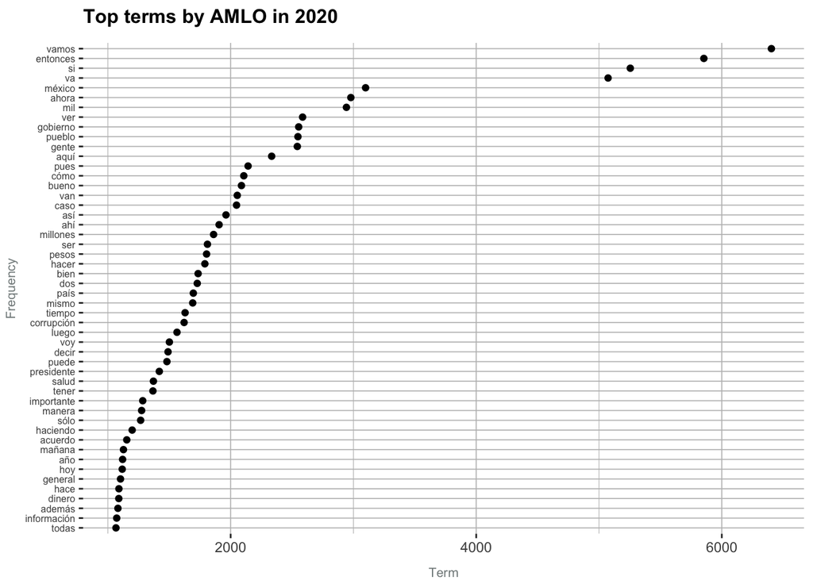

```r
#plot top features frequency
dfm_features <- textstat_frequency(dfm_president_2020, n = 50)
dfm_features$feature <- with(dfm_features, reorder(feature, +frequency))

ggplot(dfm_features, aes(x = frequency, y = feature)) +
    geom_point() +
    labs(title = "Top terms by AMLO in 2020",
        y = "Frequency", x = "Term") +
    theme(plot.title = element_text(size = 12, face = "bold", margin = margin(0, 0, 10, 0)),
        plot.subtitle = element_text(size = 10, color = "azure4", margin = margin(0, 0, 10, 0)),
        plot.caption = element_text(size = 7, color = "azure4", vjust = -2),
        axis.title.x = element_text(size = 8, color = "azure4", vjust = -2),
        axis.title.y = element_text(size = 8, color = "azure4" , vjust = 2),
        axis.text.y = element_text(size = 6),
        panel.background = element_rect(fill = 'white'),
        panel.grid.major = element_line(colour = "grey", size = 0.3),
        panel.grid.minor = element_line(colour = "grey", size = 0.2))
```

And now the second:

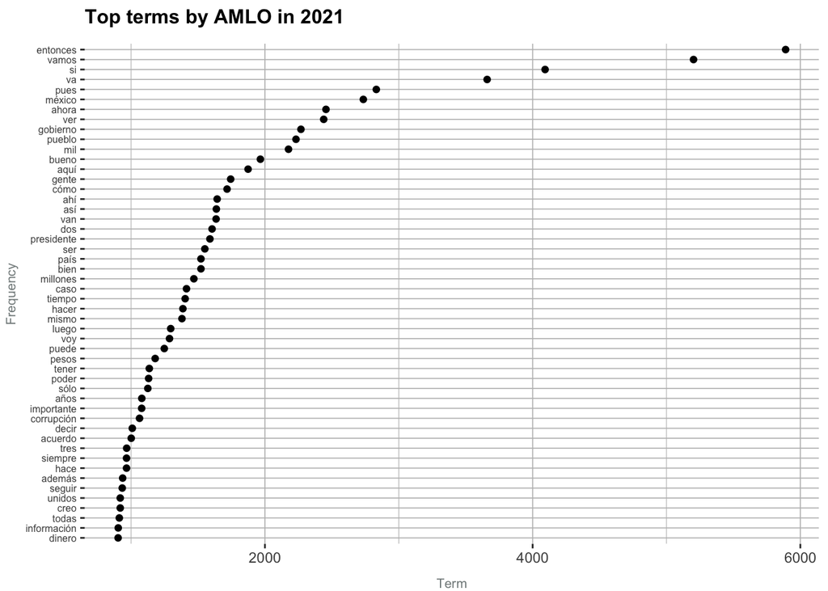

```r
#plot top features frequency
dfm_features_2 <- textstat_frequency(dfm_president_2021, n = 50)
dfm_features_2$feature <- with(dfm_features_2, reorder(feature, +frequency))

ggplot(dfm_features_2, aes(x = frequency, y = feature)) +
    geom_point() +
    labs(title = "Top terms by AMLO in 2021",
        y = "Frequency", x = "Term") +
    theme(plot.title = element_text(size = 12, face = "bold", margin = margin(0, 0, 10, 0)),
        plot.subtitle = element_text(size = 10, color = "azure4", margin = margin(0, 0, 10, 0)),
        plot.caption = element_text(size = 7, color = "azure4", vjust = -2),
        axis.title.x = element_text(size = 8, color = "azure4", vjust = -2),
        axis.title.y = element_text(size = 8, color = "azure4" , vjust = 2),
        axis.text.y = element_text(size = 6),
        panel.background = element_rect(fill = 'white'),
        panel.grid.major = element_line(colour = "grey", size = 0.3),
        panel.grid.minor = element_line(colour = "grey", size = 0.2))
```

While we don’t have any formal training whatsoever in linguistics or discourse analysis, word frequencies already hint us in very interesting directions. As we can see from the plots, the top terms don’t change much between 2020 and 2021. Perhaps the changing ranks of two terms stand out: ‘salud’ and ‘corrupción’.

The only term that could be interpreted as relating to the pandemic is ‘salud’, meaning ‘health’. The term ranks 35 in 2020 but leaves the top 50 completely in 50. Whether this is telling of the importance the pandemic had within the administration is an open question, but AMLO has in fact been criticized for downplaying it. As to ‘corrupción’ -meaning of course ‘corruption’-, the term’s rank falls from 29 in 2020 all the way to 38 in 2021. Fighting corruption is one of the key elements of the president’s rhetoric. It would be interesting to see what happened in 2019 to see if there are signs of a decreasing trend on this respect.

Since the rest of the terms don’t change much year to year, the following discussion applies to the whole corpus. The top term in 2020 is ‘vamos’, raking 2 in 2021, which is the plural first person, present tense conjugation for the verb ‘ir’, which means ‘to go’. This can be translated as ‘we go’, but is also a helper form that is used to express future tense. This is quite interesting, as it would indicate that much of what the president says is prospective and spoken from a plural perspective, possibly indicating the plans his administration and party has for the country, but also a collective approach to thing, which fits his party’s leftist ideology. The same can be said of term ‘va’, consistently ranking 4, which is the third person singular conjugation of the same verb and is used in the same fashion. This means both terms are pointing to the future. Grouping both together would only exacerbate the prospective nature of AMLOs remarks.

Another interesting trend at the top are terms ‘entonces’ and ‘si’, meaning ‘then’ and ‘if’ respectively. These are conditional clauses, which could be pointing to hypothetical thinking if they’re actually appearing together, but also if they do so separately. This all adds to a prospective gist in the presidents discourse. Finally, ‘gobierno’ (‘government’) and ‘pueblo’ (roughly ‘the people’) appear consistently on ranks 9 and 10 respectively. This is consistent with the president’s platform, which is centered around ‘the people’. Putting any hypothesis around the term ‘gobierno’ is risky, but this is in fact considered a very self-referential administration by experts, if it is telling of anything.

Finally, the country has been undergoing a very serious security crisis that hasn’t relented another AMLO. There is an ongoing war among organized crime groups, with murders, missing people, femicides, attacks on journalists and activists at all time highs. It is striking to see that no words that would directly refer us to this problem are amongst the top ranked.

## 2) Frequency and lexical dispersion analysis of COVID-19 related terms by month

In order to analyze how often COVID-19 related terms show up in President’s speech, we start off by creating a data frame for frequency of possible related terms. We get a data frame with 14 words that we identified as related to COVID-19. We plot this data frame to get a visual representation of their frequency. Later, we use lexical dispersion plots for understanding their occurrences.

Lexical dispersion marks the occurrence of terms over time and helps us visualize the frequency of these terms (like an x-ray machine). The x-axis represents the token index, whereas y-axis can be used for grouping (either time periods or different sources of material). Token index is relative or absolute, depending on whether the same text is used for comparison.

```r
#covid related freq plots
freq_interim <- subset_president_interim %>% tokens() %>% dfm() %>% textstat_frequency()

# filter the terms
freq_pandemia <- subset(freq_interim, freq_interim$feature %in% "pandemia")
freq_virus <- subset(freq_interim, freq_interim$feature %in% "virus")
freq_covid <- subset(freq_interim, freq_interim$feature %in% "covid")
freq_corona <- subset(freq_interim, freq_interim$feature %in% "corona")
freq_coronavirus <- subset(freq_interim, freq_interim$feature %in% "coronavirus")
freq_sanitaria <- subset(freq_interim, freq_interim$feature %in% "sanitaria")
freq_cuarentena <- subset(freq_interim, freq_interim$feature %in% "cuarentena")
freq_enfermedad <- subset(freq_interim, freq_interim$feature %in% "enfermedad")
freq_brote <- subset(freq_interim, freq_interim$feature %in% "brote")
freq_infeccion <- subset(freq_interim, freq_interim$feature %in% "infección")
freq_distancia <- subset(freq_interim, freq_interim$feature %in% "distancia")
freq_confinamiento <- subset(freq_interim, freq_interim$feature %in% "confinamiento")
freq_hospital <- subset(freq_interim, freq_interim$feature %in% "hospital")
freq_salud <- subset(freq_interim, freq_interim$feature %in% "salud")


freq_plot <- rbind(freq_pandemia, freq_virus, freq_covid, freq_corona, freq_coronavirus, freq_sanitaria, freq_cuarentena, freq_enfermedad, freq_brote, freq_infeccion, freq_distancia, freq_confinamiento, freq_hospital, freq_salud)

freq_plot$feature <- with(freq_plot, reorder(feature, +frequency))

freq_plot
```

|  | feature | frequency | rank | docfreq | group |
| --- | --- | --- | --- | --- | --- |
| 184 | pandemia | 1315 | 184 | 292 | all |
| 3530 | virus | 47 | 3494 | 41 | all |
| 462 | covid | 508 | 461 | 189 | all |
| 9760 | corona | 9 | 9686 | 9 | all |
| 771 | coronavirus | 294 | 769 | 76 | all |
| 2531 | sanitaria | 75 | 2513 | 57 | all |
| 8180 | cuarentena | 13 | 7898 | 10 | all |
| 2500 | enfermedad | 76 | 2491 | 56 | all |
| 11400 | brote | 7 | 11001 | 7 | all |
| 10649 | infección | 8 | 10294 | 8 | all |

[output cut: 4 more lines]

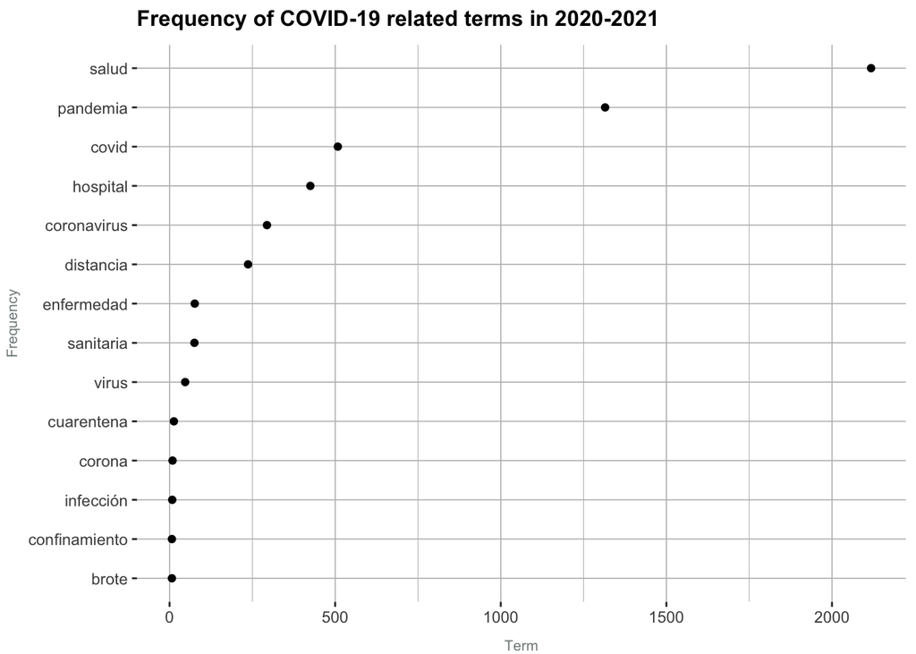

```r
ggplot(freq_plot, aes(x = frequency, y = feature)) +
    geom_point() +
    labs(title = "Frequency of COVID-19 related terms in 2020-2021",
        y = "Frequency", x = "Term") +
    theme(plot.title = element_text(size = 12, face = "bold", margin = margin(0, 0, 8, 0)),
        plot.subtitle = element_text(size = 10, color = "azure4", margin = margin(0, 0, 10, 0)),
        plot.caption = element_text(size = 7, color = "azure4", vjust = -2),
        axis.title.x = element_text(size = 8, color = "azure4", vjust = -2),
        axis.title.y = element_text(size = 8, color = "azure4" , vjust = 2),
        panel.background = element_rect(fill = 'white'),
        panel.grid.major = element_line(colour = "grey", size = 0.3),
        panel.grid.minor = element_line(colour = "grey", size = 0.2))
```

Once we identify the top words in context, we group our corpus by Month to see how specific terms were used more or less frequently over periods of time.

```r
#group by month
grouped_corpus <- corpus_group(subset_president_interim, groups = Month)
summary(grouped_corpus)
```

|  | Text | Types | Tokens | Sentences | speaker | Month |
| --- | --- | --- | --- | --- | --- | --- |
| 1 | 2020-01 | 10309 | 144866 | 5978 | Presidente Andrés Manuel López Obrador | 2020-01 |
| 2 | 2020-02 | 9483 | 111859 | 4147 | Presidente Andrés Manuel López Obrador | 2020-02 |
| 3 | 2020-03 | 9761 | 127535 | 4486 | Presidente Andrés Manuel López Obrador | 2020-03 |
| 4 | 2020-04 | 10256 | 150664 | 5339 | Presidente Andrés Manuel López Obrador | 2020-04 |
| 5 | 2020-05 | 10464 | 142719 | 4566 | Presidente Andrés Manuel López Obrador | 2020-05 |
| 6 | 2020-06 | 5819 | 50032 | 1748 | Presidente Andrés Manuel López Obrador | 2020-06 |
| 7 | 2020-07 | 8446 | 98449 | 3593 | Presidente Andrés Manuel López Obrador | 2020-07 |
| 8 | 2020-08 | 7118 | 74569 | 2525 | Presidente Andrés Manuel López Obrador | 2020-08 |
| 9 | 2020-09 | 10992 | 146081 | 4996 | Presidente Andrés Manuel López Obrador | 2020-09 |
| 10 | 2020-10 | 11584 | 152806 | 5193 | Presidente Andrés Manuel López Obrador | 2020-10 |

[output cut: 14 more lines]

We take the top words in our frequency table and plot for lexical dispersions with our grouped by Month corpus.

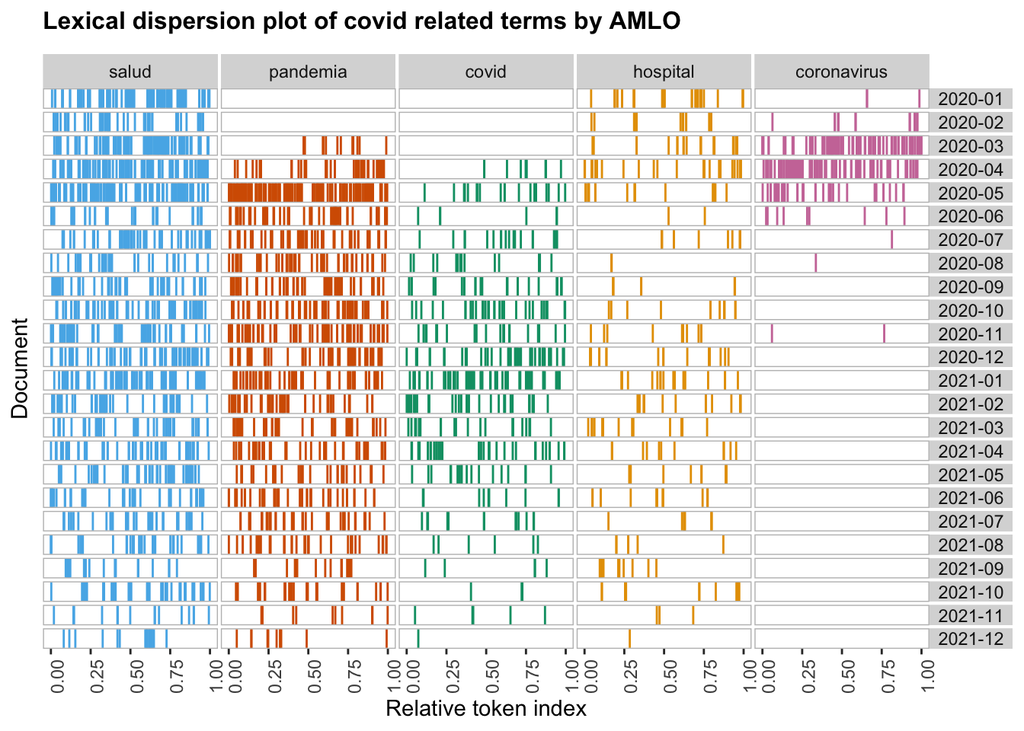

```r
#create tokens
grouped_tokens <- tokens(grouped_corpus)

#plot lexical dispersions
textplot_xray(
    kwic(grouped_tokens, pattern = "salud"),
     kwic(grouped_tokens, pattern = "pandemia"),
     kwic(grouped_tokens, pattern = "covid"),
     kwic(grouped_tokens, pattern = "hospital"),
     kwic(grouped_tokens, pattern = "coronavirus"))+
  aes(color = keyword) +
  scale_color_manual(values = c("#56B4E9", "#D55E00", "#009E73", "#E69F00", "#CC79A7")) +
  labs(title = "Lexical dispersion plot of covid related terms by AMLO") +
  theme(axis.text.x = element_text(angle = 90, hjust = 1),
        plot.title = element_text(size = 12, face = "bold", margin = margin(0, 0, 10, 0)),
        legend.position = "none")
```

The lexical dispersion plot lets us see how often each term appears in the corpus. For any given term, each cell represents a month. Since different months have different lengths and there are some days where no press conferences took place, the horizontal axis has been normalized using a relative token index. The small vertical lines indicate instances of each term being mentioned by President AMLO during his participation in the conferences. The more of these lines a given cell has, the more frequent the appearance of the term.

As we can see from the plot, the term ‘salud’ (‘health’) is the one appearing the most, even before the pandemic was declared on March. It is unclear to us why this is the case. However, it is clear the importance of the term dwindles down as time progresses. Hence, we can speculate some correlation as it appears intensively over the first outbreak, the term is too general to have a certain conclusion.

On March 11, 2020, the World Health Organization declared COVID-19 a global pandemic. Accordingly, the term ‘pandemia’ only starts showing up then, with a stark concentration on May. At least visually, this term shows the clearest “dilution” pattern as time evolves, possibly reflecting the trend of covid cases most accurately among these five terms.

The panel for term ‘coronavirus’ tells an interesting story. We can see it very frequently in March and April, even somewhat importantly in May. However, the term disappears from the scene afterwards, reflecting the move away from the term. Conspiracy theorists say this has something to do to damage being done to the Corona beer, which happens to be Mexican. Jokes aside, it is very interesting to see the term is the very first pandemic-specific (hospital and health are more general) to enter the scene, doing so in mid January.

Yet over the month of May, it seems that it is replaced by ‘covid’, as it was the case for the rest of the world. Not making an appearance until April, ‘covid’ takes over the job from ‘coronavirus’ by the summer of 2020. The intensity significantly increases over next winter months, and dwindles down after May of 2021. In the last few months of 2021, ‘covid’ rarely makes an appearance in AMLO’s speeches.

This visualization proved a very useful tool in illustrating the “intensity” of President AMLO’s focus on them as it serves as a very nice condensation of our hard work.

## 3) Exploring the trend between COVID-19 related terms and number of new cases in Mexico

Our main purpose here is to observe whether President’s statements on COVID-19 is aligned with the concern over increasing cases and the spread of the disease. In order to do this, we get COVID-19 data from World Health Organization (WHO) and compare the number of new cases in Mexico to COVID-19 terms that appear in AMLO’s speeches.

```r
#get covid case data
covid_data_df<-read.csv("https://covid19.who.int/WHO-COVID-19-global-data.csv") %>%
  filter(Country == "Mexico") %>%
  select(-Country_code,-Country,-WHO_region) %>%
  rename(doc_id = Date_reported)
```

```r
#matrix for covid related terms in 2020 and 2021
covid_dic <- dictionary(list(all_terms = c("pandemia", "covid", "coronavirus")))
dfm_covid <- tokens(subset_president_interim) %>% tokens_select(covid_dic) %>% dfm()

#add date and turn into data.frame
docnames(dfm_covid) <- docvars(dfm_covid, "Date")
covid_terms_df <- convert(dfm_covid, to = "data.frame")
covid_terms_df
```

| doc_id | coronavirus | pandemia | covid |
| --- | --- | --- | --- |
| 2020-01-02 | 0 | 0 | 0 |
| 2020-01-03 | 0 | 0 | 0 |
| 2020-01-06 | 0 | 0 | 0 |
| 2020-01-07 | 0 | 0 | 0 |
| 2020-01-08 | 0 | 0 | 0 |
| 2020-01-09 | 0 | 0 | 0 |
| 2020-01-10 | 0 | 0 | 0 |
| 2020-01-13 | 0 | 0 | 0 |
| 2020-01-14 | 0 | 0 | 0 |
| 2020-01-15 | 0 | 0 | 0 |

[output cut: 409 more lines]

```r
covid_terms_df <- covid_terms_df %>% mutate(total_freq = (pandemia + covid + coronavirus))
final_df <- left_join(covid_terms_df, covid_data_df)
final_df
```

| doc_id | coronavirus | pandemia | covid | total_freq | New_cases | Cumulative_cases | New_deaths | Cumulative_deaths |
| --- | --- | --- | --- | --- | --- | --- | --- | --- |
| 2020-01-02 | 0 | 0 | 0 | 0 | NA | NA | NA | NA |
| 2020-01-03 | 0 | 0 | 0 | 0 | 0 | 0 | 0 | 0 |
| 2020-01-06 | 0 | 0 | 0 | 0 | 0 | 0 | 0 | 0 |
| 2020-01-07 | 0 | 0 | 0 | 0 | 0 | 0 | 0 | 0 |
| 2020-01-08 | 0 | 0 | 0 | 0 | 0 | 0 | 0 | 0 |
| 2020-01-09 | 0 | 0 | 0 | 0 | 0 | 0 | 0 | 0 |
| 2020-01-10 | 0 | 0 | 0 | 0 | 0 | 0 | 0 | 0 |
| 2020-01-13 | 0 | 0 | 0 | 0 | 0 | 0 | 0 | 0 |
| 2020-01-14 | 0 | 0 | 0 | 0 | 0 | 0 | 0 | 0 |
| 2020-01-15 | 0 | 0 | 0 | 0 | 0 | 0 | 0 | 0 |

[output cut: 409 more lines]

```r
weekly_df <- final_df %>%
  mutate(Month = substring(doc_id , 1,7))%>%
  group_by(Month)%>%
    summarise_at(.vars = vars(total_freq,New_cases, New_deaths),
               .funs = c(mean="mean"))
```

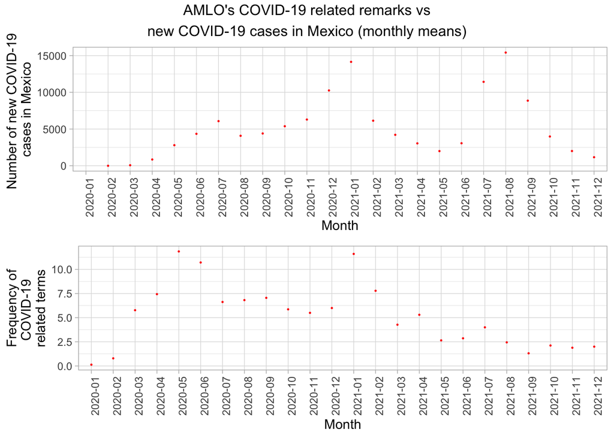

```r
coef <- 1000

#weekly cases
weekly_cases <- ggplot(weekly_df, aes(x=Month)) +
  geom_point( aes(y=New_cases_mean), size=0.2, color = "red") +
  scale_y_continuous(name = "Number of new COVID-19 \ncases in Mexico") +
  theme_light()+
  theme(axis.text.x = element_text(angle = 90, hjust = 1))

#weekly freq
weekly_freq <- ggplot(weekly_df, aes(x=Month)) +
  geom_point( aes(y=total_freq_mean), size=0.2, color = "red") +
  scale_y_continuous(name = "Frequency of\nCOVID-19 \nrelated terms") +
  theme_light()+
  theme(axis.text.x = element_text(angle = 90, hjust = 1))

grid.arrange(weekly_cases,
             weekly_freq,
             ncol = 1,
             top = "AMLO's COVID-19 related remarks vs\nnew COVID-19 cases in Mexico (monthly means)")
```

Finally, the last plot allows us to tackle our main question, which was how connected was President AMLO’s rhetoric to the developments in the pandemic, as measured by new cases. To interpret this graph, we care more about the shapes than anything else.

As we can see from the top panel, August, 2021 exhibits the largest mean number of cases in the whole plot, meaning the pandemic had reached a very severe point. One would expect the president’s discourse to at least peak then, if not have its own largest peak, but it doesn’t do either. The combinen frequencies of the terms most specifically related to the pandemic -covid, pandemic and coronavirus- do not follow the severity of the health crisis.

While venturing hypotheses is risky, it is the kind of exercise that is able to produce stories. A poorly objective pro-AMLO journalist might interpret this as an attempt to bring the country back to normality, and a way to avoid the confluence of factors that made 2020 one of the worst years in economic terms for the country. An unprofessional anti-AMLO researcher might see this as irresponsible conduct which fosters the spread of the virus and endangers human lives.

Since we are neither, and we aspire to become data scientists that work for the advancement of the public good, we can only say there is a disconnect here. However, let us say this. Being able to compare this two plots and objectively show this disconnect exists is already a success. By traversing the data science pipeline of scraping, parsing, analyzing and communicating, we went from what were pretty much blog-posts online to the very interesting aforementioned fact. Moreover, the potencial of every intermediate product -the text files, the parsed speeches, the aggregation- is enormous if properly channeled.

Our work needs a lot of polishing, yes. But we believe it showcases a lot of the things we have learned during the course, others we have sought and others stumbled upon along the way, and works non only as an illustration of our newly-acquired abilities as data scientists, but already as a very interesting prototype that could live on after the course.